# Support Vector Regression

Author : Rose Ellison

Given a set of data points, $\{(x_1, z_1), \ldots, (x_l, z_l)\}$, such that $x_i \in R^n$ is an input and $z_i \in R^1$ is a target output, the standard form of support vector regression is:
$$\begin{eqnarray*}
\min_{w,b,\xi,\xi^*} &&\frac{1}{2}
w^Tw
+ C \sum_{i=1}^l
\xi_i
+ C \sum_{i=1}^l
\xi_i^*
\\
&& z_i - w^T \phi(x_i) - b \leq
\epsilon + \xi_i , \\
&& w^T \phi(x_i) + b -z_i\leq
\epsilon + \xi_i^* , \\
&& \xi_i, \xi_i^* \geq 0,
i = 1, \ldots, l.
\end{eqnarray*}$$

# Preparing the Data

```r
# Set the seed
set.seed(1)

# Importing the data
positions <- read.csv('../../data/Position_Salaries.csv')

# Examine the Data
dim(positions)
```

```
## [1] 10  3
```

```r
positions
```

```
##             Position Level  Salary
## 1   Business Analyst     1   45000
## 2  Junior Consultant     2   50000
## 3  Senior Consultant     3   60000
## 4            Manager     4   80000
## 5    Country Manager     5  110000
## 6     Region Manager     6  150000
## 7            Partner     7  200000
## 8     Senior Partner     8  300000
## 9            C-level     9  500000
## 10               CEO    10 1000000
```

From the table we can see there is some redundancy between the $Position$ and $Level$ column. Therefor it would make sense to drop the $Position$ column and just use the numeric $Level$ and $Salary$ columns. Since we only have 10 observations, it would not be useful to split the data into a training and test set.

```r
# Saving the dataset with only the two necessary columns
positions <- positions[, 2:3]
```

## SVR Regressor

```r
regressor <- svm(formula = Salary ~ Level,
                 data = positions,
                 type = 'eps-regression')
```

## Predicting a Result

```r
y.pred <- predict(regressor, data.frame(Level = 6.5))
```

## Visualizing the SVR

Visualizing the data will allow us to see if the SVR is a good model for the data.

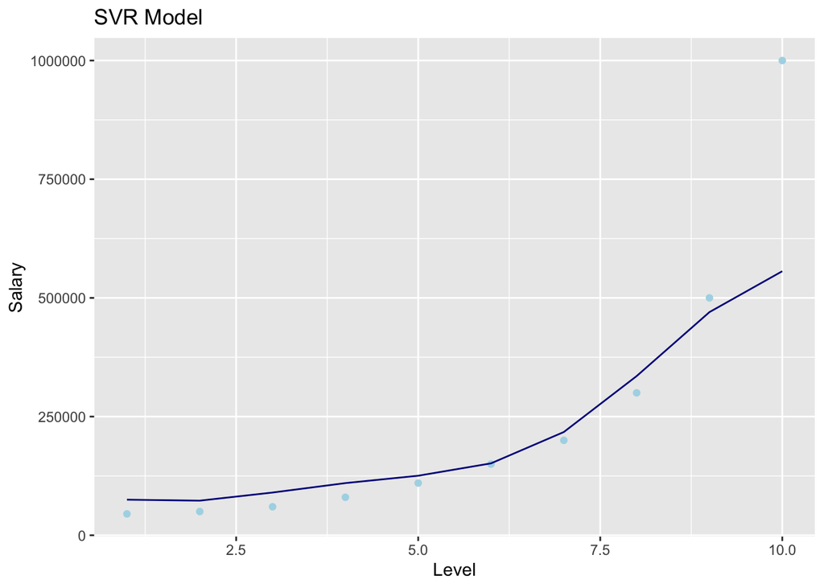

```r
# Visualizing the Polynomial Linear Regression
ggplot() +
  geom_point(data = positions, aes(x = Level, y = Salary), col = 'lightblue') +
  geom_line(aes(x = positions$Level, y = predict(regressor, newdata = positions)), col = 'darkblue') +
  ggtitle('SVR Model') +
  xlab('Level') +
  ylab('Salary')
```

## Conclusion

This model fits well with all of the data EXCEPT the CEO level. The CEO can also be categorized as an outlier. It is clear that the SVR model is not calculating any outliers in it’s model.